# Initial EDA of Hourly OD Data

Author

Drew Galloro

# First Pass

## Load in 2018 Data

```r
library(tidyverse)
```

Let’s start by loading in one of the datasets and poking around

```r
dir = "../data/date-hour-soo-dest-"
od_2018 <- read_csv(paste(dir,"2018.csv", sep = ""),
        col_names = c(
            "date",
            "hour",
            "origin",
            "destination",
            "ridership"
        ))
head(od_2018)
```

```
# A tibble: 6 × 5
  date        hour origin destination ridership
  <date>     <dbl> <chr>  <chr>           <dbl>
1 2018-01-01     0 12TH   12TH                3
2 2018-01-01     0 12TH   16TH                1
3 2018-01-01     0 12TH   BAYF                1
4 2018-01-01     0 12TH   CAST                3
5 2018-01-01     0 12TH   CIVC                2
6 2018-01-01     0 12TH   CONC                2
```

The data contains date, hour, origin and destination (OD) data. The first row tells us that three people got on at 12th street in oakland and got off at 12th street in the first hour of January 1st, 2018. (Maybe people realizing that they missed new years eve in SF). We’re assuming that the hour variable represents the hour that a person exited their destination station, as an OD pair is not formed until a destination is chosen.

```r
dim(od_2018)
```

```
[1] 10227631        5
```

The data itself does not contain many features, but the number of observations is massive. There are $10,227,631$ “observations” in the dataset. Each hour of the day for each hour of the year, and the potential for $50*49 + 50 = 2500$ different OD pair combinations for each date-hour pair.

```r
size <- format(object.size(od_2018), units = "Gb")
cat("The estimated size of this tibble is:", size, "\n")
```

```
The estimated size of this tibble is: 0.4 Gb
```

It should be noted that when reading in the data this was the table with the largest number of observations. I expect the other data to be similarly sized.

## Ridership

Let’s look at the ridership column specifically:

```r
summary(od_2018$ridership)
```

```
   Min. 1st Qu.  Median    Mean 3rd Qu.    Max.
   1.00    1.00    3.00   11.78    9.00 1165.00
```

It’s worth noting that any datetime-OD pairings that did not have riders (i.e. would have ridership 0), are not in the dataset. We may want to add them back in if possible. Or, when we add lag variables, like the ridership of an OD pair from the previous hour, we will have to set it to zero if it is not present in the data.

```r
od_2018[which.max(od_2018$ridership),]
```

```
# A tibble: 1 × 5
  date        hour origin destination ridership
  <date>     <dbl> <chr>  <chr>           <dbl>
1 2018-08-24    23 COLS   DUBL             1165
```

It’s funny to note that the largest singular hour of ridership for an OD pair was a Raiders vs the Greenbay Packers Game. We may be able to use this to discern whether the hour variable records the hour at Origin or Destination.

## Trends for Specific OD Pair

Let’s choose some specific OD pairs and plot their ridership over time:

```r
print(count(od_2018, origin), n = 50)
```

```
# A tibble: 48 × 2
   origin      n
   <chr>   <int>
 1 12TH   279142
 2 16TH   286890
 3 19TH   276201
 4 24TH   278387
 5 ANTC    98952
 6 ASHB   212186
 7 BALB   242688
 8 BAYF   215802
 9 CAST   141302
10 CIVC   318316
11 COLM   153478
12 COLS   246080
```

[output cut: 36 more lines]

```r
print(count(od_2018, destination), n = 50)
```

```
# A tibble: 48 × 2
   destination      n
   <chr>        <int>
 1 12TH        274386
 2 16TH        278892
 3 19TH        268291
 4 24TH        274806
 5 ANTC        104879
 6 ASHB        211055
 7 BALB        234021
 8 BAYF        218973
 9 CAST        146740
10 CIVC        309185
11 COLM        154006
12 COLS        248645
```

[output cut: 36 more lines]

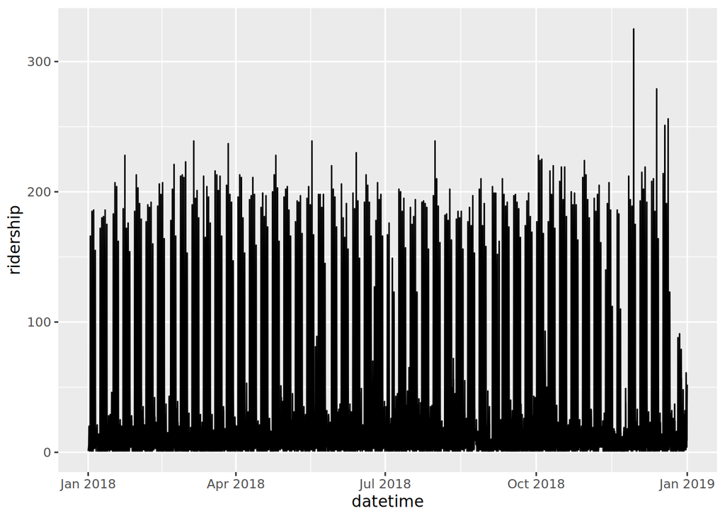

```r
od_2018 |>
    filter((origin == "PLZA") & (destination == "EMBR")) |>
    mutate(datetime = date + dhours(hour)) |>
    ggplot(aes(x = datetime, y = ridership)) +
        geom_line()
```

Let’s limit it to a certain hour:

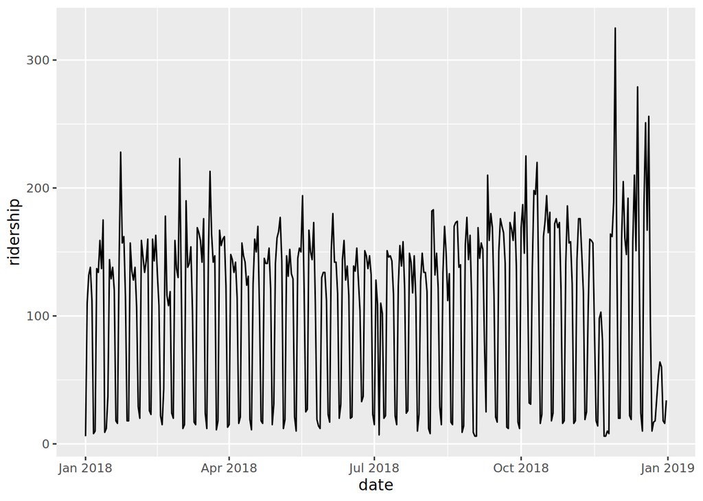

```r
od_2018 |>
    filter((origin == "PLZA") &
            (destination == "EMBR") &
            (hour == 9)) |>
    ggplot(aes(x = date, y = ridership)) +
        geom_line()
```

Let’s limit it to a certain date

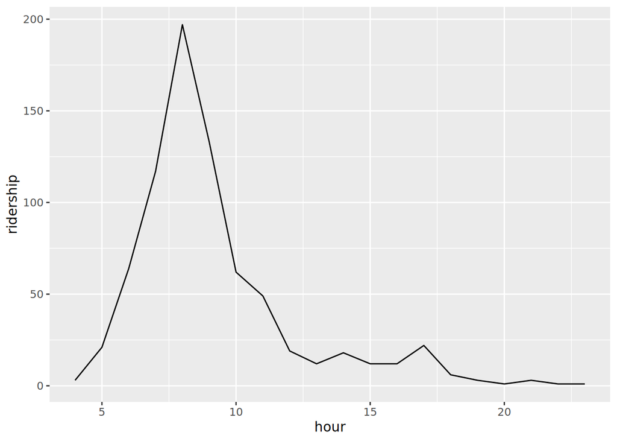

```r
od_2018 |>
    filter((origin == "PLZA") &
            (destination == "EMBR") &
            (date == ymd("2018-05-10"))) |>
    ggplot(aes(x = hour, y = ridership)) +
        geom_line()
```

```r
wday("2018-05-10", label = TRUE)
```

```
[1] Thu
Levels: Sun < Mon < Tue < Wed < Thu < Fri < Sat
```

We’ll have to see if similar trends exhibit on other OD pairs. This one is fairly straightforward. Variable ridership, likely lower on weekends and higher on commute days. On a specific weekday, ridership for this OD pair is highest in the morning and then it drops off. This is because we’re not considering the return trip, which is a separate OD pair. We may want to bring these together as a station pair instead of an ordered pair.

## Potential Changes to Data

- We may need to add in missing datetime-OD pairs as having 0 ridership
- We may be able to discern using the Raiders vs. Green Bay Packers game whether the hour is recorded at origin or destination
- We may want to write data as station pairings instead of OD pairings. e.g. combining `PLZA` -> `EMBR` and `EMBR` -> `PLZA` ridership.
- We could maybe add a time-of-day indicator
- We could add a destination zone variable (e.g. by county? “Alameda”, “San Francisco”, “Contra Costa”, etc.)

# Second Pass

Let’s add some initial features to the dataset. Since the initial eda I have merged the data into one csv file.

```r
# remove old table from memory
rm(od_data)
# load in merged csv file.
od_data <- read_csv("../data/od-data.csv")
```

## First Set of Features

We’ll start by adding an indicator for pre/post Covid. The first mandatory stay at home order was issued on March 19th, 2020. Therefore, we will add a feature that is 1 if the datetime is on March 20, 2020 or afterwards. As well as a feature for day of week. BART splits the data in their monthly reports by “Weekday,” “Saturday,” and “Sunday.” We will do the same.

```r
od_data <- od_data |> mutate(post_covid = if_else(date > ymd("2020-03-19"), 1, 0),
                                day = case_when(wday(date) %in% seq(2, 6) ~ "weekday",
                                                wday(date) == 1 ~ "sunday",
                                                wday(date) == 7 ~ "saturday")
                        )
```

Now that we’ve added these features, let’s see which days and destinations have the largest mean ridership:

```r
od_data |> group_by(day, destination) |> summarize(riders = mean(ridership)) |> arrange(desc(riders)) |> head(10)
```

```
`summarise()` has regrouped the output.
ℹ Summaries were computed grouped by day and destination.
ℹ Output is grouped by day.
ℹ Use `summarise(.groups = "drop_last")` to silence this message.
ℹ Use `summarise(.by = c(day, destination))` for per-operation grouping
  (`?dplyr::dplyr_by`) instead.
```

```
# A tibble: 10 × 3
# Groups:   day [3]
   day      destination riders
   <chr>    <chr>        <dbl>
 1 weekday  EMBR         26.8
 2 weekday  MONT         24.4
 3 weekday  POWL         15.8
 4 weekday  CIVC         13.8
 5 saturday POWL         13.5
 6 saturday EMBR         10.9
 7 sunday   POWL         10.4
 8 weekday  12TH          9.31
 9 weekday  19TH          9.26
10 weekday  24TH          9.25
```

Let’s plot distributions of riderships based on destination station:

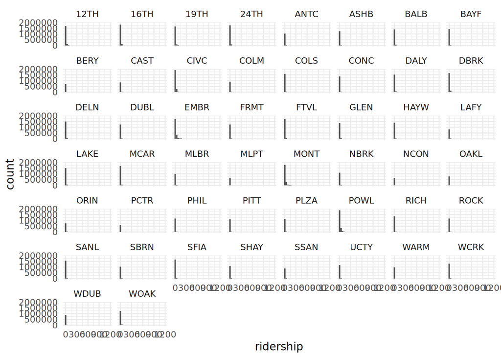

```r
od_data |> ggplot() +
                geom_histogram(aes(x = ridership), bins = 30) +
                facet_wrap(~ destination) +
                theme_minimal()
```

It appears that the ridership is heavily right skewed, with a few instances of really high ridership. We may want to do a log-transform on the data. Let’s focus on a few specific destination stations.

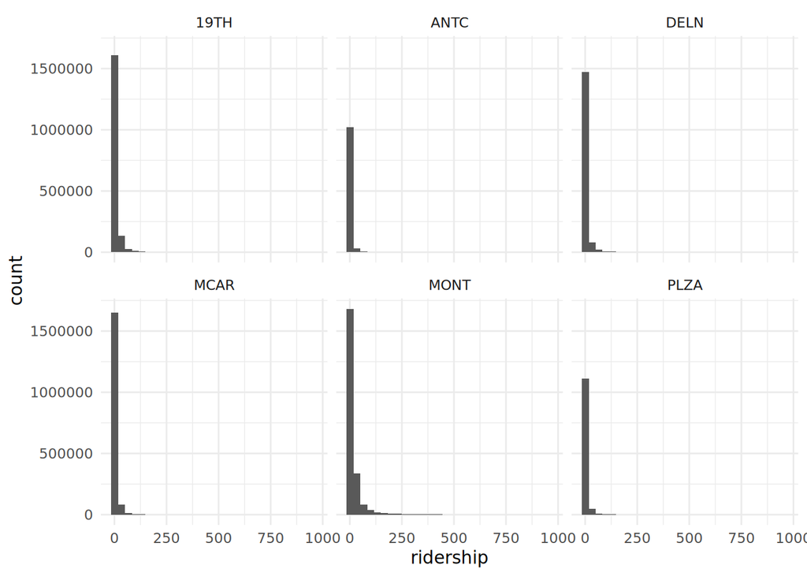

```r
stations <- od_data |> distinct(destination)

od_data |> filter(destination %in% sample(stations$destination, 6)) |>
                ggplot() +
                        geom_histogram(aes(x = ridership), bins = 30) +
                        facet_wrap(~ destination) +
                        theme_minimal()
```